# C7 Week 1

# Linear least squares

## Some basic notation and background

When we have pairs of data $(X_i,Y_i)$ we define the (sample/empirical) covariance and the correlation as follows

$$Cov\left(X,Y\right) =
\dfrac{1}{n-1}\sum_{i=1}^{n}\left(X_i \bar{X}\right)\left(Y_i -
\bar{Y}\right) = \dfrac{1}{n-1}\sum_{i=1}^{n}\left(X_iY_i -
n\bar{X}\bar{Y}\right)$$

$$Cor\left(X,Y\right) = \dfrac{Cov\left(X,Y\right)}{S_xS_y}$$
where $S_x$ and $S_y$ are the sample standard deviation of $X$ and $Y$, respectively.

### Properties of correlation

- $Cor(X,Y) = Cor(Y,X)$
- $-1 \leq Cor(X,Y) \leq 1$
- $Cor(X,Y) = \pm 1$ only when the $X$ and $Y$ observations fall perfectly on a positive or negative sloped line, respectively.
- $Cor(X,Y)$ measures the strength of linear relationship between the $X$ and $Y$ data, with stronger relationships as $Cor(X,Y)$ heads towards $\pm 1$.
- $Cor(X,Y)= 0$ implies no **linear** relationship

## Linear Least Squares

The estimators for $\beta_0$ and $\beta_1$ can be derived following several approaches. One of those is the one called **least squares method** for which we define the **residual** as the difference between the observed value and the predicted value. That is to say

$$e_i = Y_{i} - \left(\underbrace{\beta_0 + \beta_1x_i}_{\text{The
predicted $Y_i$ value}}\right)$$
Then, the linear least squares method involves to calculate the values of $\beta_0$ and $\beta_1$ that minimizes the sum of squares of the residuals, which is a two variable function:
$$Q\left(\beta_0,\beta_1\right) = \sum_{i=1}^n{e_i^2} =
\sum_{i=1}^{n}{\left(Y_i - \beta_0 - \beta_1x_i\right)^2}$$
and from which, using Calculus, we can prove that
$$\hat{\beta_0} = \bar{Y} - \hat{\beta_1}\bar{x} \hspace{5ex}
\hat{\beta_1} = \dfrac{S_{xY}}{s_x^2} = r_{xy}\dfrac{S_y}{S_x}$$
we can see that the units of $\hat{\beta_1}$ are the units of $\dfrac{Y}{X}$ whereas the units of $\hat{\beta_0}$ are the units of $Y$.

# Regression to the mean

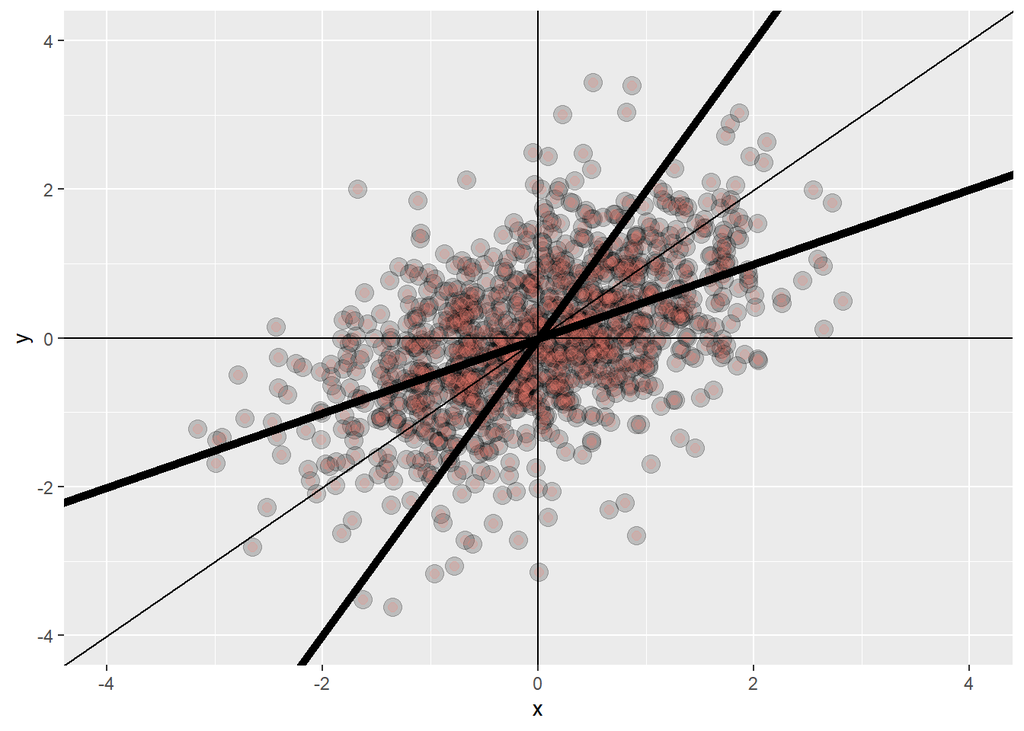

```r
library(UsingR)
data(father.son)
y <- (father.son$sheight - mean(father.son$sheight))/sd(father.son$sheight)
x <- (father.son$fheight - mean(father.son$fheight))/sd(father.son$fheight)
rho <- cor(x,y)
library(ggplot2)
g <- ggplot(data.frame(x = x, y = y), aes(x = x, y = y))
g <- g + geom_point(size = 4, colour = "black", alpha = 0.2)
g <- g + geom_point(size = 2, colour = "salmon", alpha = 0.2)
g <- g + xlim(-4,4) + ylim(-4,4)
g <- g + geom_abline(intercept = 0, slope = 1)
g <- g + geom_vline(xintercept = 0)
g <- g + geom_hline(yintercept = 0)
g <- g + geom_abline(intercept = 0, slope = rho, size = 2)
g <- g + geom_abline(intercept = 0, slope = 1/rho, size = 2)
g
```

Comments: note that the correlation $\rho$ measures the extent of the regression to the mean, as every prediction would be obtained by multiplying $\rho\cdot x$.